# GTFS Trolley String Lines

Varun Bhakhri 2024-08-15

- Project Description:
- Code Setup
- Instructions:
- A test string line chart outlining each step in the process:
- Create functions for processing time:
- Create a test string line chart for one route, one direction and one season:
- Plot the String Line Chart for one route and direction
- Create a function to create string lines for each trolley route and direction for a single season.
- Run the function to create string lines for routes 10, 11, 13, 15, 34, 36
- Export string lines for all available seasons:

### Project Description:

This markdown outlines the process of creating string line charts to represent scheduled trips for each trolley route, in each direction and for each available Fall/Spring season for which GTFS static data was published by SEPTA.

The code also exports the string line charts into folders for each season.

The GTFS files can be found at [SEPTA’s GitHub Page](https://github.com/septadev/GTFS/tags)

### Code Setup

Install and load packages:

```r
# List of required packages
required_packages <- c("tidyverse", "tidytransit", "lubridate", "here", "hms")

# Function to install and load packages if not already installed
install_and_load <- function(packages) {
  for (pkg in packages) {
    if (!requireNamespace(pkg, quietly = TRUE)) {
      install.packages(pkg)
    }
    library(pkg, character.only = TRUE)
  }
}

# Install and load all required packages
install_and_load(required_packages)
```

### Instructions:

Create a folder named “GTFS Data” and store required GTFS bus files here. This code will create a folder by the same name if it does not already exist:

```r
gtfs_data_folder <- here("GTFS Data")

if (!dir.exists(gtfs_data_folder)) {
  dir.create(gtfs_data_folder)
  message("Folder 'GTFS Data' created.")
} else {
  message("Folder 'GTFS Data' already exists.")
}
```

```
## Folder 'GTFS Data' already exists.
```

Select the years and seasons for which string line charts are to be generated:

```r
years <- 2016:2024
seasons <- c("Fall", "Spring")

season_list <- expand.grid(season = seasons, year = years) %>%
  arrange(year, season) %>%
  mutate(season_name = paste(season, year))
```

Select the routes for which string line charts are to be generated:

```r
routes_list <- c("10", "11", "13", "15", "34", "36")
```

### A test string line chart outlining each step in the process:

Methodology:

1. Load the GTFS Data
2. Create functions to better process time variables
3. Filter the Stop Times table by Route and Direction.
4. Filter the Stop Times table by the most appropriate Service ID that represents Trip IDs covering the entire day and occours the most number of times in a season. 5)Represent each trip ID as a string line over the course of a day, colour coded by time periods.

The following steps break down each process to create the string line charts:

Load GTFS Data from the “GTFS Data” folder

```r
gtfs_data_spring_2024 <- read_gtfs(here("GTFS Data", "google_bus_Spring 2024.zip"))
```

### Create functions for processing time:

Function to convert time strings to seconds:

```r
time_to_seconds <- function(time_string) {
  if (!is.na(time_string)) {
    hms <- strsplit(time_string, ":")[[1]]
    as.numeric(hms[1]) * 3600 + as.numeric(hms[2]) * 60 + as.numeric(hms[3])
  } else {
    NA_real_  # Return NA as a numeric value
  }
}
```

Function to calculate time periods based on the first digit of the column

```r
time_periods <- function(numerical) {
  case_when(
    between(numerical, 0, 6.99) ~ "00.00 - 07.00 - Early Morning",
    between(numerical, 7, 8.99) ~ "07.00 - 09.00 - AM Rush",
    between(numerical, 9, 16.99) ~ "09.00 - 17.00 - Midday",
    between(numerical, 17, 19.99) ~ "17.00 - 20.00 - PM Rush",
    between(numerical, 20, 23.99) ~ "20.00 - 24.00 - Night"
  )
}
```

### Create a test string line chart for one route, one direction and one season:

Save individual GTFS tables:

```r
routes <- gtfs_data_spring_2024$routes
trips <- gtfs_data_spring_2024$trips
stop_times <- gtfs_data_spring_2024$stop_times
calendar_dates <- gtfs_data_spring_2024$calendar_dates
stops <- gtfs_data_spring_2024$stops
```

Filter Route 10:

```r
trips_data <- trips %>%
  filter(route_id == "10" & !trip_headsign == "40th-Market")
```

Get unique directions for the route, excluding “40th-Market”

```r
directions <- trips_data %>%
    filter(trip_headsign != "40th-Market") %>%
    pull(trip_headsign) %>%
    unique()
```

Filter trips in one direction by choosing one Trip Headsign

```r
trips_direction <- trips_data %>%
      filter(trip_headsign == "13th-Market")
```

Filter Service IDs for weekday trips

```r
weekday_service_ids <- calendar_dates %>%
  mutate(weekday = wday(date, label = TRUE)) %>%  # Add a column for the day of the week
  filter(!weekday %in% c("Sun", "Sat")) %>%       # Exclude weekends
  pull(service_id)
```

Find common Service IDs that exists in both trips_data and calendar_dates

```r
common_service_ids <- weekday_service_ids[weekday_service_ids %in% trips_data$service_id]
```

```r
filtered_calendar_dates <- calendar_dates %>%
      filter(service_id %in% common_service_ids)
```

Join the filtered calendar dates with trips on the selected route and direction

```r
trips_dates <- right_join(trips_direction, filtered_calendar_dates, by = "service_id") %>%
      filter(!is.na(trip_id))
```

Arrange Service IDs by most to least run patterns across the filtered calendar dates

```r
trips_per_service_id <- trips_dates %>%
      group_by(date, service_id) %>%
      count(date) %>%
      arrange(desc(n))
```

Extract the Service ID with the most patterns

```r
best_service_id <- trips_per_service_id[1,] %>%   # Sort by count in descending order
      pull(service_id)
```

Filter all trips that run on the selected Service ID

```r
trips_selected <- trips_direction %>%
    filter(service_id == best_service_id)
```

Filter the stop times corresponding to the selected patterns and convert time variables to more usable formats

```r
trip_stop_times <- stop_times %>%
    filter(trip_id %in% trips_selected$trip_id) %>%
    mutate(
      departure_time = as.character(departure_time),
      departure_seconds = sapply(departure_time, time_to_seconds),
      departure_hours = departure_seconds / 3600,
      time_periods = time_periods(departure_hours),
      arrival_time = as.POSIXct(arrival_time, format = "%H:%M:%S", tz = "UTC")
    ) %>%
    arrange(trip_id, stop_sequence)
```

### Plot the String Line Chart for one route and direction

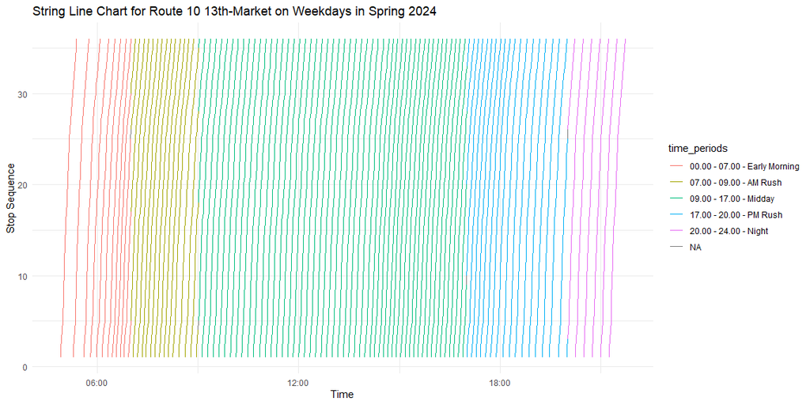

```r
ggplot(trip_stop_times, aes(x = arrival_time, y = stop_sequence, color = time_periods, group = trip_id)) +
        geom_line() +
        labs(
          title = paste("String Line Chart for Route", "10", "13th-Market", "on Weekdays", "in Spring 2024"),
          x = "Time",
          y = "Stop Sequence"
        ) +
        scale_x_datetime(date_labels = "%H:%M") +
        theme_minimal()
```

### Create a function to create string lines for each trolley route and direction for a single season.

Methodology: Run for loops that cycle through each Route and Direction

```r
create_string_line_chart <- function(gtfs_data_spring_2024, routes_list) {
  routes <- gtfs_data_spring_2024$routes
  trips <- gtfs_data_spring_2024$trips
  stop_times <- gtfs_data_spring_2024$stop_times
  calendar_dates <- gtfs_data_spring_2024$calendar_dates
  stops <- gtfs_data_spring_2024$stops

  for (route in routes_list) {
    # Filter the routes table to find the correct route_id
    route_data <- routes %>%
      filter(route_id == route)

    if (nrow(route_data) == 0) {
      message(paste("Route", route, "not found in GTFS data. Skipping..."))
      next
    }

    trips_data <- trips %>%
      filter(route_id == route_data$route_id)

    # Get unique directions for the route, excluding "40th-Market"
    directions <- trips_data %>%
      filter(trip_headsign != "40th-Market") %>%
      pull(trip_headsign) %>%
      unique()

    for (direction in directions) {
      trips_direction <- trips_data %>%
        filter(trip_headsign == direction)

      weekday_service_ids <- calendar_dates %>%
        mutate(weekday = wday(date, label = TRUE)) %>%  # Add a column for the day of the week
        filter(!weekday %in% c("Sun", "Sat")) %>%       # Exclude weekends
        pull(service_id)                                # Extract the service_id values

      # Find common service_ids that exists in both trips_data and calendar_dates
      common_service_ids <- weekday_service_ids[weekday_service_ids %in% trips_direction$service_id]

      if (length(common_service_ids) == 0) {
        message(paste("No common service_id found for route", route, "and direction", direction, ". Skipping..."))
        next
      }

      filtered_calendar_dates <- calendar_dates %>%
        filter(service_id %in% common_service_ids)

      trips_dates <- right_join(trips_direction, filtered_calendar_dates, by = "service_id") %>%
        filter(!is.na(trip_id))

      trips_per_service_id <- trips_dates %>%
        group_by(date, service_id) %>%
        count(date) %>%
        arrange(desc(n))

      best_service_id <- trips_per_service_id[1, ] %>%
        pull(service_id)

      trips_on_date <- trips_direction %>%
        filter(service_id == best_service_id)

      trip_stop_times <- stop_times %>%
        filter(trip_id %in% trips_on_date$trip_id) %>%
        mutate(
          departure_time = as.character(departure_time),
          departure_seconds = sapply(departure_time, time_to_seconds),
          departure_hours = departure_seconds / 3600,
          time_periods = time_periods(departure_hours),
          arrival_time = as.POSIXct(arrival_time, format = "%H:%M:%S", tz = "UTC")
        ) %>%
        arrange(trip_id, stop_sequence)

      trip_stop_times_with_names <- trip_stop_times %>%
        left_join(stops, by = "stop_id") %>%
        mutate(stop_name_number = paste(stop_sequence, stop_name, sep = "_"))

      string_chart <- ggplot(trip_stop_times_with_names, aes(x = arrival_time, y = stop_sequence, color = time_periods, group = trip_id)) +
        geom_line() +
        labs(
          title = paste("String Line Chart for Route", route, " Trips to", direction, "on Weekdays", "in Spring 2024"),
          x = "Time",
          y = "Stop Sequence"
        ) +
        scale_x_datetime(date_labels = "%H:%M") +
        theme_minimal()
     output_path <- here("String Lines Exports", paste0("gtfs_route_", route, "_", gsub(" ", "_", direction), "_Weekday_string_line_chart.jpg"))
      ggsave(output_path, plot = string_chart, width = 4000, height = 1750, units = "px")
      print(string_chart)
    }
  }
}
```

### Run the function to create string lines for routes 10, 11, 13, 15, 34, 36

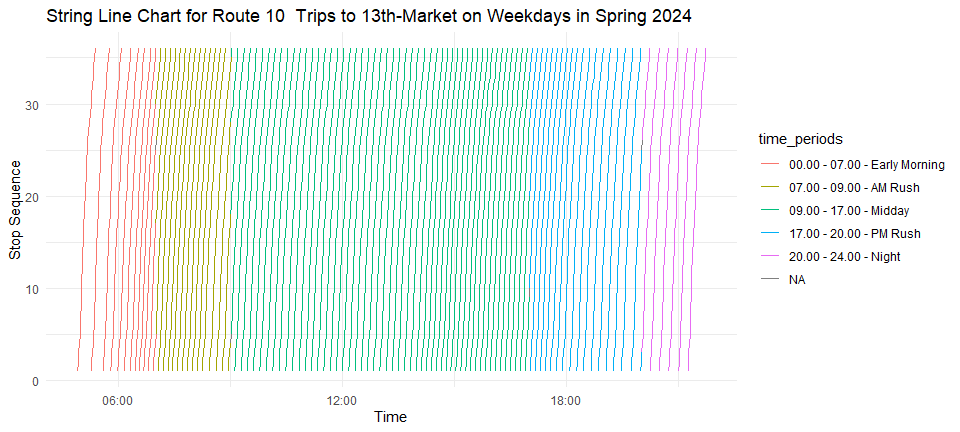

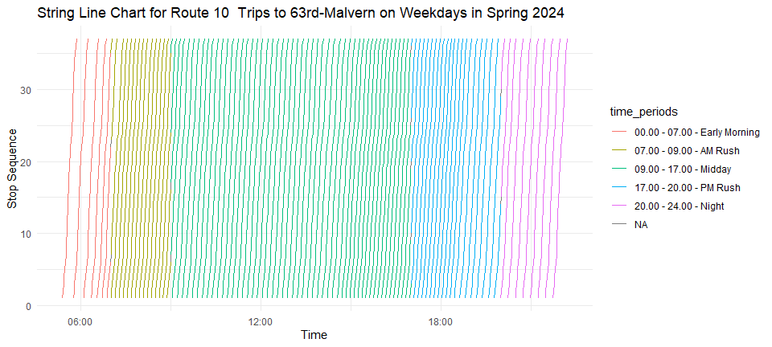

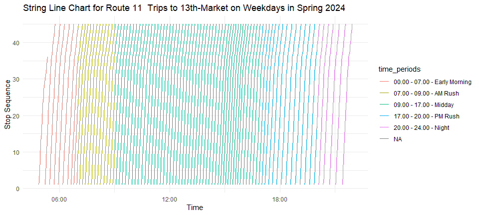

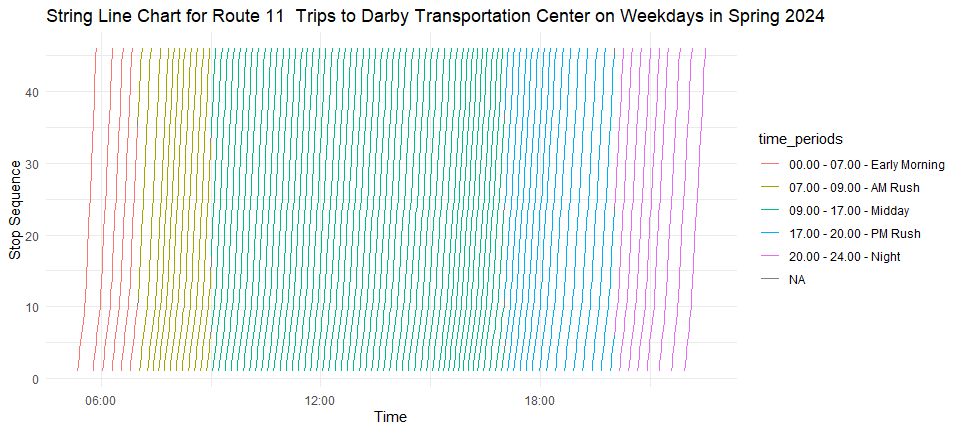

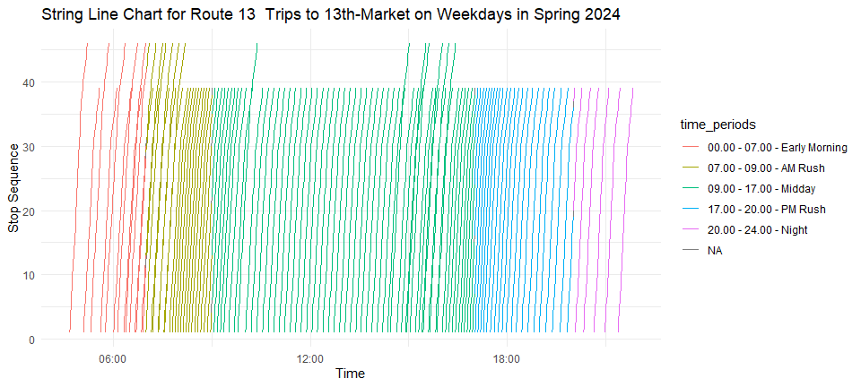

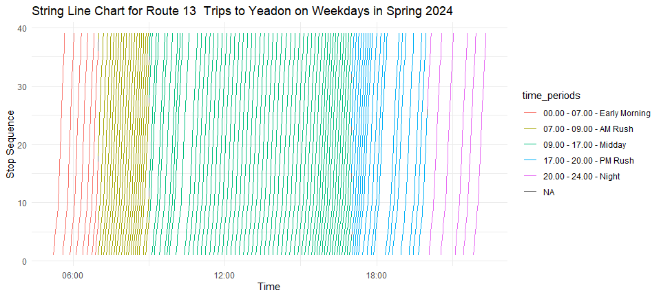

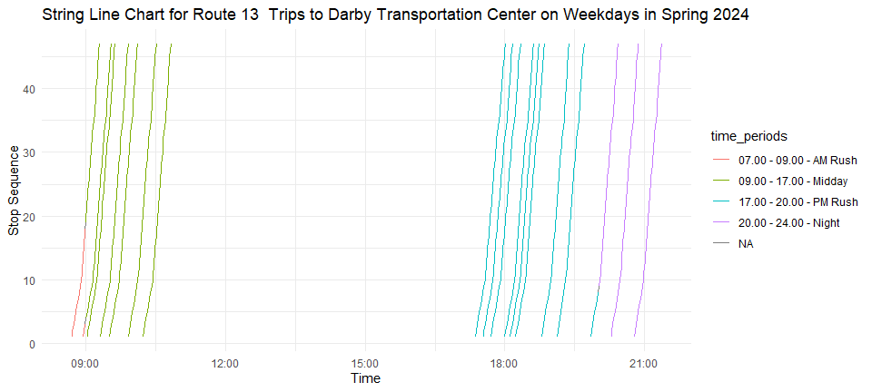

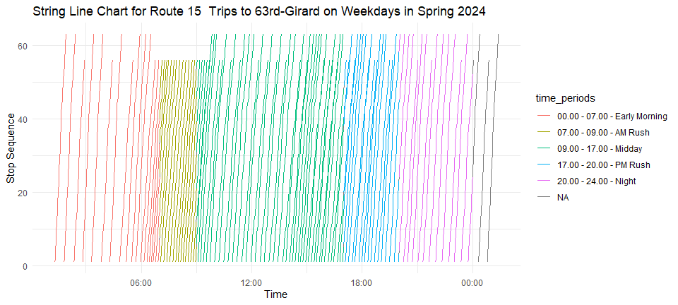

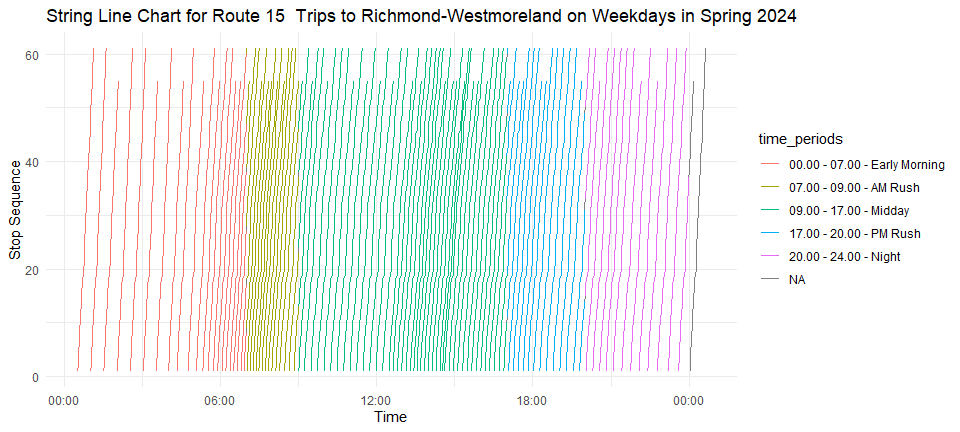

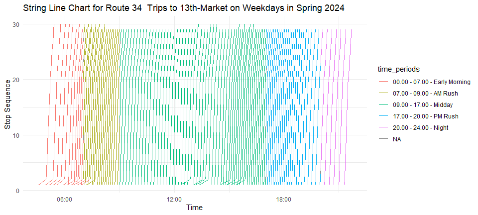

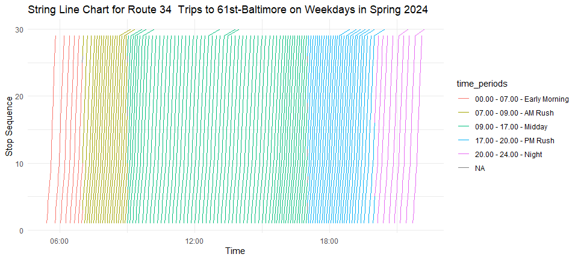

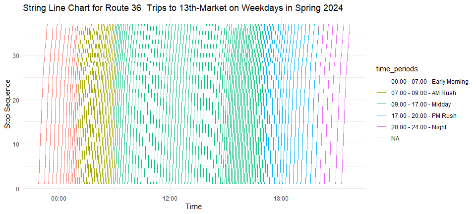

[1 more figures not shown]

```r
create_string_line_chart(gtfs_data_spring_2024, c("10", "11", "13", "15", "34", "36"))
```

### Export string lines for all available seasons:

Methodology: Run for loops that cycle through each Route, Direction and Season

Create a function to create string lines for all available seasons:

```r
create_string_line_chart_seasons <- function(gtfs_data, routes_list, season) {
  routes <- gtfs_data$routes
  trips <- gtfs_data$trips
  stop_times <- gtfs_data$stop_times
  calendar_dates <- gtfs_data$calendar_dates
  stops <- gtfs_data$stops

  for (route in routes_list) {
    # Filter the routes table to find the correct route_id
    route_data <- routes %>%
      filter(route_id == route)

    if (nrow(route_data) == 0) {
      message(paste("Route", route, "not found in GTFS data. Skipping..."))
      next
    }

    trips_data <- trips %>%
      filter(route_id == route_data$route_id)

    # Get unique directions for the route, excluding "40th-Market"
    directions <- trips_data %>%
      filter(trip_headsign != "40th-Market") %>%
      pull(trip_headsign) %>%
      unique()

    for (direction in directions) {
      trips_direction <- trips_data %>%
        filter(trip_headsign == direction)

      weekday_service_ids <- calendar_dates %>%
        mutate(weekday = wday(date, label = TRUE)) %>%  # Add a column for the day of the week
        filter(!weekday %in% c("Sun", "Sat")) %>%       # Exclude weekends
        pull(service_id)                                # Extract the service_id values

      # Find common service_ids that exist in both trips_data and calendar_dates
      common_service_ids <- weekday_service_ids[weekday_service_ids %in% trips_direction$service_id]

      if (length(common_service_ids) == 0) {
        message(paste("No common service_id found for route", route, "and direction", direction, ". Skipping..."))
        next
      }

      filtered_calendar_dates <- calendar_dates %>%
        filter(service_id %in% common_service_ids)

      trips_dates <- right_join(trips_direction, filtered_calendar_dates, by = "service_id") %>%
        filter(!is.na(trip_id))

      trips_per_service_id <- trips_dates %>%
        group_by(date, service_id) %>%
        count(date) %>%
        arrange(desc(n))

      best_service_id <- trips_per_service_id[1, ] %>%
        pull(service_id)

      trips_on_date <- trips_direction %>%
        filter(service_id == best_service_id)

      trip_stop_times <- stop_times %>%
        filter(trip_id %in% trips_on_date$trip_id) %>%
        mutate(
          departure_time = as.character(departure_time),
          departure_seconds = sapply(departure_time, time_to_seconds),
          departure_hours = departure_seconds / 3600,
          time_periods = time_periods(departure_hours),
          arrival_time = as.POSIXct(arrival_time, format = "%H:%M:%S", tz = "UTC")
        ) %>%
        arrange(trip_id, stop_sequence)

      trip_stop_times_with_names <- trip_stop_times %>%
        left_join(stops, by = "stop_id") %>%
        mutate(stop_name_number = paste(stop_sequence, stop_name, sep = "_"))

      string_chart <- ggplot(trip_stop_times_with_names, aes(x = arrival_time, y = stop_sequence, color = time_periods, group = trip_id)) +
        geom_line() +
        labs(
          title = paste("String Line Chart for Route", route, "Trips to", direction, "on Weekdays", season),
          x = "Time",
          y = "Stop Sequence"
        ) +
        scale_x_datetime(date_labels = "%H:%M") +
        theme_minimal()

      # Create the season-specific folder inside "String Lines Exports"
      season_folder <- here("String Lines Exports", season)
      if (!dir.exists(season_folder)) {
        dir.create(season_folder, recursive = TRUE)
      }

      output_path <- file.path(season_folder, paste0("gtfs_route_", route, "_", gsub(" ", "_", direction), "_Weekday_string_line_chart.jpg"))
      ggsave(output_path, plot = string_chart, width = 4000, height = 1750, units = "px")
      print(string_chart)
    }
  }
}
```

Loop over each season and create string line charts for each route, and save in their respective folders:

[output not shown]

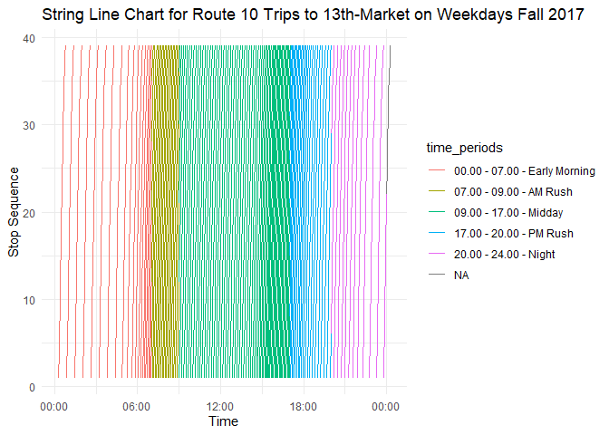

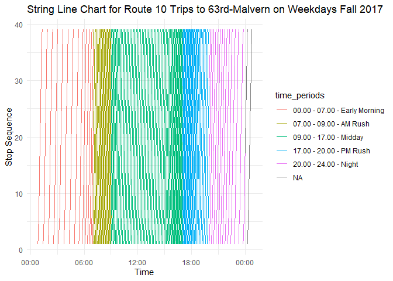

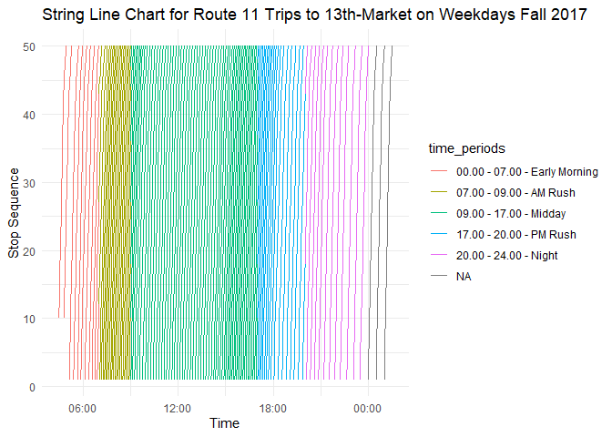

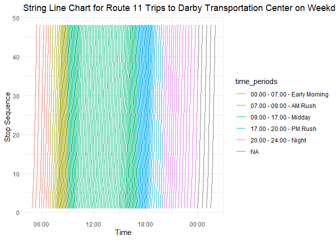

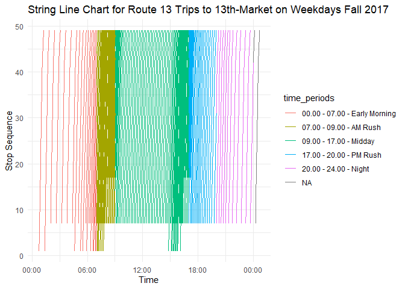

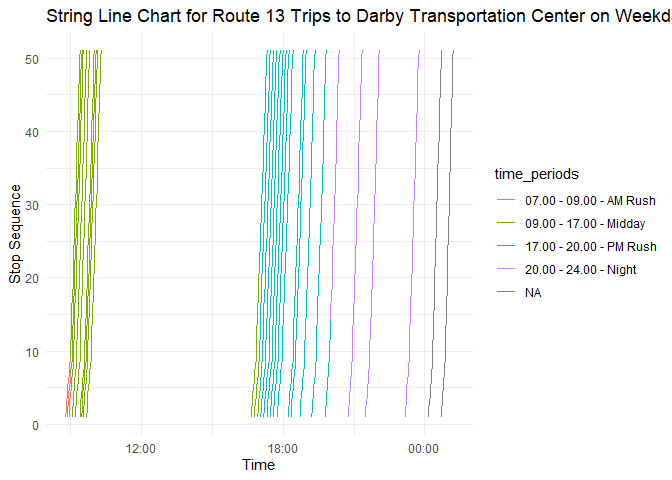

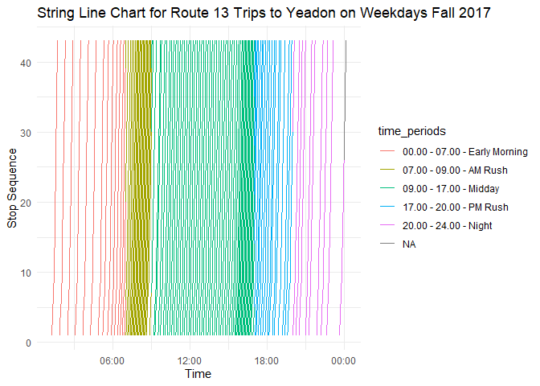

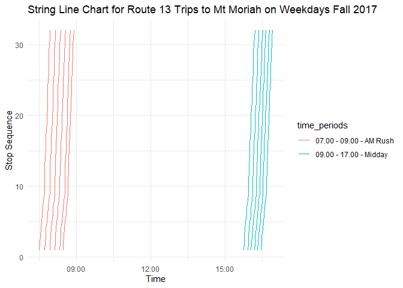

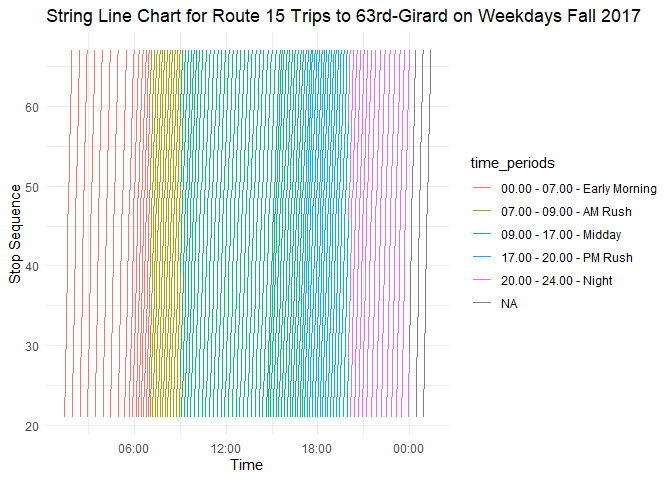

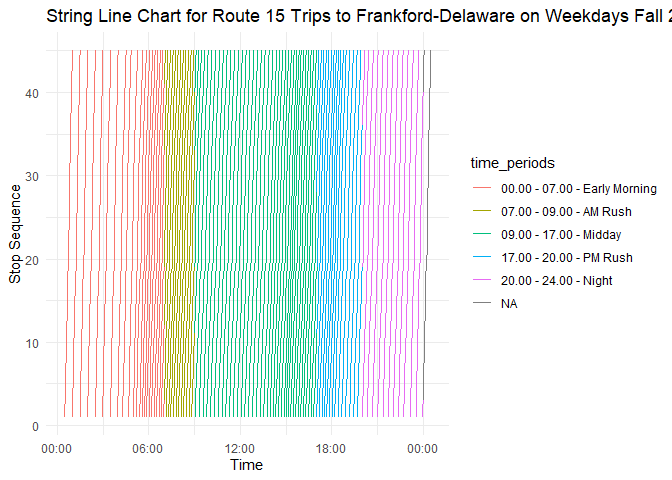

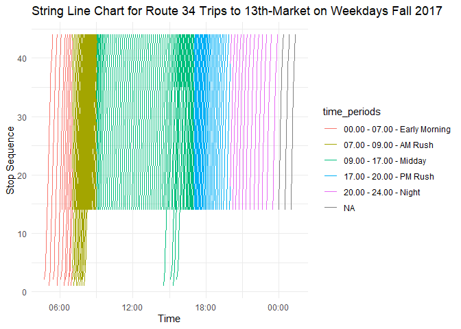

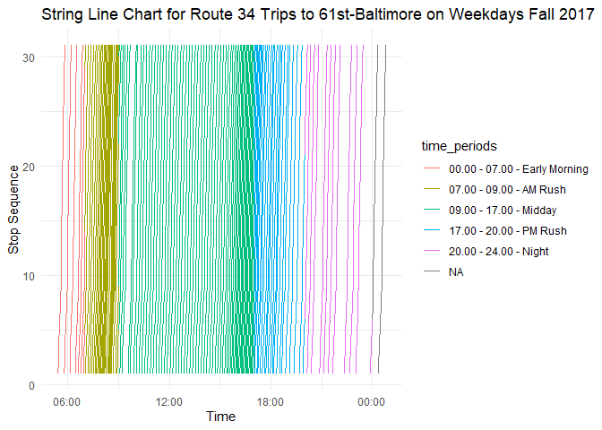

[143 more figures not shown]

```r
for (season in season_list$season_name) {
  gtfs_file <- here("GTFS Data", paste0("google_bus_", season, ".zip"))

  if (!file.exists(gtfs_file)) {
    message(paste("GTFS file for", season, "not found. Skipping..."))
    next
  }

  gtfs_data <- read_gtfs(gtfs_file)

  create_string_line_chart_seasons(gtfs_data, routes_list, season)
}
```